# Practical Machine Learning Course Project

Wesley Simons

July 16, 2017

## Wesley Simons Practical Machine Learning Course Project

### Loading the libraries and data.

First we will load the required libraries, and the data files from the local machine.

```r
library(caret)
library(tidyverse)
library(rattle)

train.dat<-file.choose()
test.dat<-file.choose()
trainingSet<-read.csv(train.dat)
testingSet<-read.csv(test.dat)
```

### Preparing the data sets for analysis.

Next we will create a data partition with the training set to build our model and test our prediction.

```r
set.seed(1234)
inTrain<- createDataPartition(trainingSet$classe, p=.75, list=FALSE)
wesTraining<-trainingSet[inTrain,]
wesTesting<-trainingSet[-inTrain,]
```

After our partitions are created we need to clean the data.

```r
#remove the first two columns as they are not related to our analysis.
wesTraining<-wesTraining[,-c(1:2)]
#remove all columns with more than 50% N/A values.
na.names<-c(NULL)
for(i in 1:length(wesTraining)) {
  if(sum( is.na( wesTraining[, i] ) ) /nrow(wesTraining) >= .5) {
    na.names<-c(na.names,i)
  }
}
wesTraining<-wesTraining[,-na.names]
#remove the variables with near zero variance
nearzero<-nearZeroVar(wesTraining, saveMetrics = TRUE)
wesTraining<-wesTraining[,nearzero$nzv==FALSE]
#remove timestamp columns
wesTraining<-wesTraining[,-c(1:4)]
```

In the final data preparation step we will need to make sure that all of our data sets share the same variables.

```r
#make training and testing sets the same
clean.names<-names(wesTraining)
wesTesting<-wesTesting[clean.names]
#make final testing set the same
testingSet<-testingSet[clean.names[-53]]
dim(wesTraining)
```

```
## [1] 14718    53
```

```r
dim(wesTesting)
```

```
## [1] 4904   53
```

```r
#the testingSet data.frame will have one less column as it does not contain the "classe" variable.
dim(testingSet)
```

```
## [1] 20 52
```

### Building the Models

#### Decision Tree

We will evaluate a few different models to try and find one that accurately predicts the classe (form break) outcome. We will start with using the rpart package to build a decision tree.

```r
modfit.rpart<-train(classe~.,data=wesTraining, method="rpart")
predict.rpart<-predict(modfit.rpart, newdata=wesTesting[,-57])
conf.rpart<-confusionMatrix(predict.rpart, wesTesting$classe)
conf.rpart$overall[1]
```

```
## Accuracy
##  0.49531
```

#### Random Forest

Since our decision tree accuracy was so poor, we will next try a random forest model.

```r
modfit.rf<-train(classe~.,data=wesTraining, method="rf", trControl=trainControl(method="cv", number=4))
predict.rf<-predict(modfit.rf, newdata=wesTesting[,-57])
conf.rf<-confusionMatrix(predict.rf, wesTesting$classe)
conf.rf$overall[1]
```

```
##  Accuracy
## 0.9938825
```

```r
varImp(modfit.rf)
```

```
## rf variable importance
##
##   only 20 most important variables shown (out of 52)
##
##                      Overall
## roll_belt             100.00
## pitch_forearm          60.41
## yaw_belt               56.62
## pitch_belt             43.88
## magnet_dumbbell_z      42.90
## roll_forearm           42.76
## magnet_dumbbell_y      42.52
## accel_dumbbell_y       22.82
## roll_dumbbell          17.78
## accel_forearm_x        16.90
## magnet_dumbbell_x      16.86
## magnet_belt_z          14.91
## magnet_forearm_z       14.48
## accel_belt_z           13.73
## accel_dumbbell_z       13.65
## total_accel_dumbbell   12.53
## gyros_belt_z           11.66
## yaw_arm                11.58
## magnet_belt_y          11.38
## magnet_belt_x           9.89
```

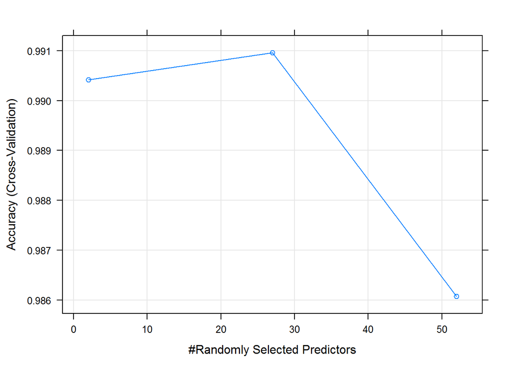

```r
plot(modfit.rf)
```

### Predicting on the testing set

Finally, we will need to predict the classe variable for our testing set.

```r
predict.test<-predict(modfit.rf, newdata = testingSet)
predict.test
```

```
##  [1] B A B A A E D B A A B C B A E E A B B B
## Levels: A B C D E
```